# Clustering

## 1. DBSCAN

Using DBSCAN iterate (for-loop) through different values of `min_samples` (1 to 10) and `epsilon` (.05 to .5, in steps of .01) to find clusters in the road-data used in the Lesson and calculate the Silohouette Coeff for `min_samples` and `epsilon`. Plot *one* line plot with the multiple lines generated from the min_samples and epsilon values. Use a 2D array to store the SilCoeff values, one dimension represents `min_samples`, the other represents epsilon.

Expecting a plot of `epsilon` vs `sil_score`.

```python
import numpy as np
import pandas as pd
%matplotlib inline
import matplotlib.pyplot as plt

from mpl_toolkits import mplot3d

from sklearn.cluster import DBSCAN
from sklearn import metrics

plt.rcParams['font.size'] = 14
```

```python
# Load the data
file = 'C:/Users/jomors/OneDrive/_JHU/AS.470.667 Machine Learning/mlnn-main/data/3D_spatial_network.txt.gz'
# Rename column headings as they load
X = pd.read_csv(file, header=None, names=['osm', 'lat','lon','alt'])
X = X.drop(['osm'], axis=1).sample(10000)   # sample should take a random sample of the data loaded
X.head()
```

|  | lat | lon | alt |
| --- | --- | --- | --- |
| 311358 | 11.179962 | 57.322866 | 2.019803 |
| 83702 | 9.503374 | 56.922242 | 24.698545 |
| 251765 | 9.740749 | 57.296361 | 8.437094 |
| 209399 | 10.538270 | 57.463233 | 1.411779 |
| 193568 | 9.489505 | 56.775696 | 36.337757 |

```python
# Make a copy of the data and normalize the columns
XX = X.copy()
XX['alt'] = (X.alt - X.alt.mean())/X.alt.std()
XX['lat'] = (X.lat - X.lat.mean())/X.lat.std()
XX['lon'] = (X.lon - X.lon.mean())/X.lon.std()
XX.head()
```

|  | lat | lon | alt |
| --- | --- | --- | --- |
| 311358 | 2.317207 | 0.827437 | -1.080755 |
| 83702 | -0.358606 | -0.550832 | 0.126130 |
| 251765 | 0.020242 | 0.736252 | -0.739248 |
| 209399 | 1.293075 | 1.310342 | -1.113112 |
| 193568 | -0.380740 | -1.054995 | 0.745530 |

```python
# Create our ranges of values to cycle through.
min_samples = np.arange(1, 11)
epsilons = np.arange(.05, .55, .05)
```

```python
# Initialize an empty array
all_scores = []

# Loop through the min_samples values
for min_sample in min_samples:
    #scores = []

    # Loop through the epsilon values
    for epsilon in epsilons:
        # Create the DBSCAN model with the current min_sample and epsilon values
        dbscan = DBSCAN(eps=epsilon, min_samples=min_sample)

        # Fit the model
        cluster = dbscan.fit_predict(XX[['lat','lon', 'alt']])

        # calculate silouette score here
        score = metrics.silhouette_score(XX[['lon', 'lat', 'alt']], cluster)

        # Append the values into a 3D array
        #scores.append(score)
        all_scores.append([min_sample, epsilon, score])

    #all_scores.append(scores)
```

```python
# Convert the 3D array to a data frame
results = pd.DataFrame(all_scores)
# Assign meaningful column names
results.columns = ['min_samples', 'epsilon', 'sil_score']
results

#results = np.array(min_samples, epsilons, all_scores)
```

|  | min_samples | epsilon | sil_score |
| --- | --- | --- | --- |
| 0 | 1 | 0.05 | 0.173288 |
| 1 | 1 | 0.10 | -0.208377 |
| 2 | 1 | 0.15 | -0.677241 |
| 3 | 1 | 0.20 | -0.545692 |
| 4 | 1 | 0.25 | -0.464297 |
| ... | ... | ... | ... |
| 95 | 10 | 0.30 | 0.100371 |
| 96 | 10 | 0.35 | 0.102618 |
| 97 | 10 | 0.40 | 0.120641 |
| 98 | 10 | 0.45 | 0.141536 |
| 99 | 10 | 0.50 | 0.138930 |

100 rows × 3 columns

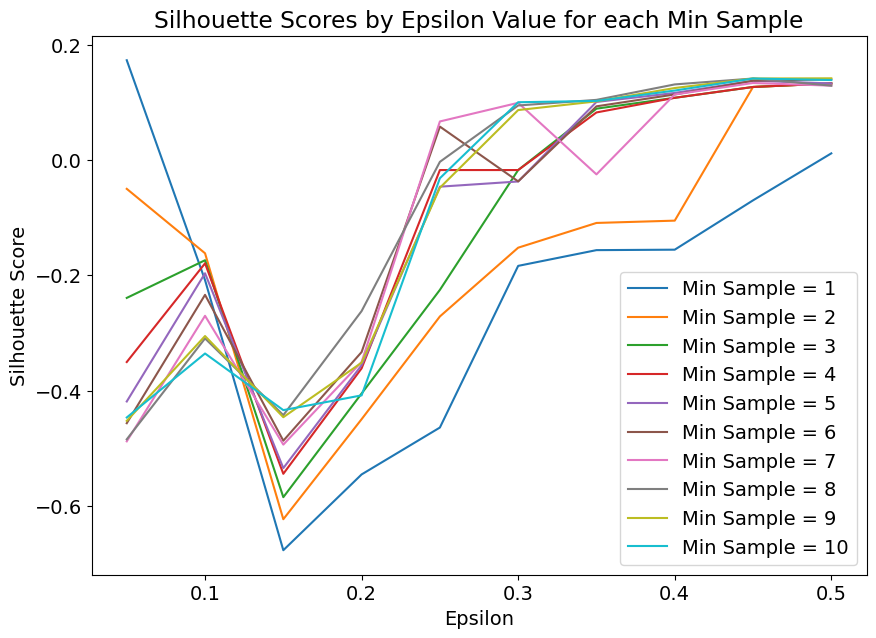

```python
plt.rcParams['figure.figsize'] = (10.0, 7.0)

# Create a Figure and an Axes with plt.subplots
fig, ax = plt.subplots()

# Loop through the min_samples values to create
# a separate line plot for each min_sample value.
for min_sample in min_samples:
    ax.plot(results[results.min_samples==min_sample].epsilon,
            results[results.min_samples==min_sample].sil_score,
            label='Min Sample = ' + str(min_sample))

# Set labels and titles
ax.set_xlabel('Epsilon')
ax.set_ylabel('Silhouette Score')
ax.legend(loc='best')
ax.set_title("Silhouette Scores by Epsilon Value for each Min Sample")

# Display the line chart
plt.show()
```

## 2. Clustering your own data

Using your own data, find relevant clusters/groups within your data (repeat the above). If your data is labeled with a class that you are attempting to predict, be sure to not use it in training and clustering.

You may use the labels to compare with predictions to show how well the clustering performed using one of the clustering metrics (http://scikit-learn.org/stable/modules/clustering.html#clustering-performance-evaluation).

If you don't have labels, use the silhouette coefficient to show performance. Find the optimal fit for your data but you don't need to be as exhaustive as above.

Additionally, show the clusters in 2D or 3D plots.

As a bonus, try using PCA first to condense your data from N columns to less than N.

Two items are expected:

- Metric Evaluation Plot (like in 1.)
- Plots of the clustered data

```python
from sklearn.datasets import load_wine
wine = load_wine()
winedf = pd.DataFrame(wine.data, columns=wine.feature_names)
winedf.head()
```

|  | alcohol | malic_acid | ash | alcalinity_of_ash | magnesium | total_phenols | flavanoids | nonflavanoid_phenols | proanthocyanins | color_intensity | hue | od280/od315_of_diluted_wines | proline |
| --- | --- | --- | --- | --- | --- | --- | --- | --- | --- | --- | --- | --- | --- |
| 0 | 14.23 | 1.71 | 2.43 | 15.6 | 127.0 | 2.80 | 3.06 | 0.28 | 2.29 | 5.64 | 1.04 | 3.92 | 1065.0 |
| 1 | 13.20 | 1.78 | 2.14 | 11.2 | 100.0 | 2.65 | 2.76 | 0.26 | 1.28 | 4.38 | 1.05 | 3.40 | 1050.0 |
| 2 | 13.16 | 2.36 | 2.67 | 18.6 | 101.0 | 2.80 | 3.24 | 0.30 | 2.81 | 5.68 | 1.03 | 3.17 | 1185.0 |
| 3 | 14.37 | 1.95 | 2.50 | 16.8 | 113.0 | 3.85 | 3.49 | 0.24 | 2.18 | 7.80 | 0.86 | 3.45 | 1480.0 |
| 4 | 13.24 | 2.59 | 2.87 | 21.0 | 118.0 | 2.80 | 2.69 | 0.39 | 1.82 | 4.32 | 1.04 | 2.93 | 735.0 |

The **wine** dataset is a sample dataset included with scikit-learn. This includes a set of target data that classifies the observations into 3 types. Thus, we shoudl expect 3 classifications of the dataset.

Here, I start with a PCA decomposition of the data into 3 variables. This facilitates 3D plotting.

```python
# Apply PCA to reduce to 3 variables for easy plotting
from sklearn.decomposition import PCA

pca = PCA(n_components=3)
wine_pca = pca.fit(wine.data).transform(wine.data)
wine_pca
```

[output not shown]

[output cut: 123 more lines]

[output not shown]

Next, I plot the 3 new variables from the PCA model and color the results based on the original classification provided in the **wine** dataset.

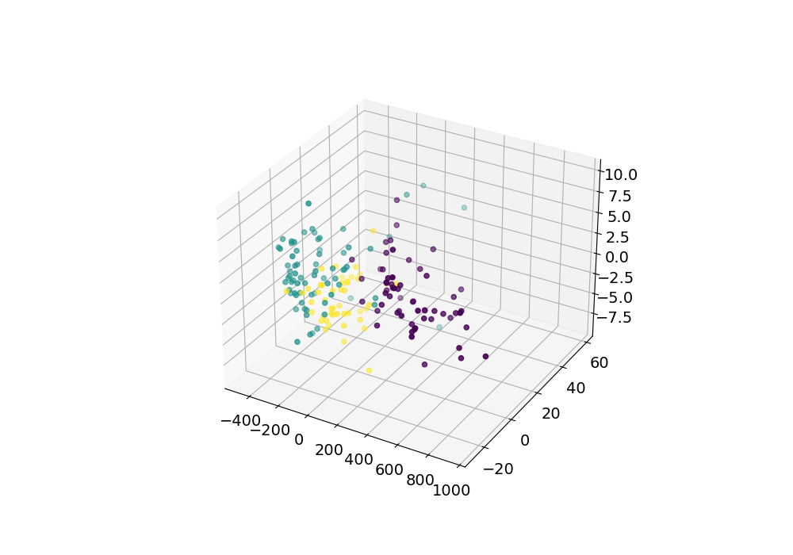

```python
fig = plt.figure()
ax = plt.axes(projection='3d')

ax.scatter3D(wine_pca[:,0], wine_pca[:,1], wine_pca[:,2], c=wine.target, cmap='viridis')

plt.show()
```

Next, I cycle through the **epsilon** and **min_samples** values as in part 1, applying a DBSCAN classification on the variables that came from the PCA decomposition.

```python
results = pd.DataFrame(wine_pca, columns=['one', 'two', 'three'])

# Initialize an empty array
wine_scores = []

# Loop through the min_samples values
for min_sample in min_samples:

    # Loop through the epsilon values
    for epsilon in epsilons:
        # Create the DBSCAN model with the current min_sample and epsilon values
        dbscan = DBSCAN(eps=epsilon, min_samples=min_sample)

        # Fit the model
        #cluster = dbscan.fit_predict(wine_pca)
        cluster = dbscan.fit_predict(results[['one', 'two', 'three']])

        # calculate silouette score here
        score = metrics.silhouette_score(results[['one', 'two', 'three']], cluster)

        # Append the values into a 3D array
        #scores.append(score)
        wine_scores.append([min_sample, epsilon, score])
```

[output not shown]

[output cut: 9 more lines]

[output not shown]

```python
dbscan = DBSCAN(eps=0.3, min_samples=5)
#winesmall = wine.data[:,10:13]
cluster = dbscan.fit_predict(wine_pca.data)

#cluster = dbscan.fit_predict(winesmall)
#cluster = dbscan.fit_predict(wine.data)
#winedf.cluster.value_counts()
```

```python
results = pd.DataFrame(wine_pca, columns=['one', 'two', 'three'])
results['cluster'] = cluster
#silhouette_score(wine_pca, cluster)
results
```

[output not shown]

178 rows × 4 columns

```python
#metrics.silhouette_score(XX[['lon', 'lat', 'alt']], XX.cluster)
metrics.silhouette_score(results[['one', 'two', 'three']], cluster)
```

[output not shown]

It seems I am unable to get the DBSCAN and silhouette score to work with this data. I tried several different data sets and could not get valid results. Always I had a single classifier, and could not get scores.

Just for the effort to do something, I will do a KMeans Cluster here instead, as that seems to work much better with the data.

```python
pca_data = pd.DataFrame(wine_pca, columns=['one', 'two', 'three'])

N = 3
from sklearn.cluster import KMeans
km = KMeans(n_clusters=N, random_state=1)
km.fit(pca_data)
pca_data['cluster'] = km.predict(pca_data)
pca_data.cluster.value_counts()
```

```
cluster
0    69
2    62
1    47
Name: count, dtype: int64
```

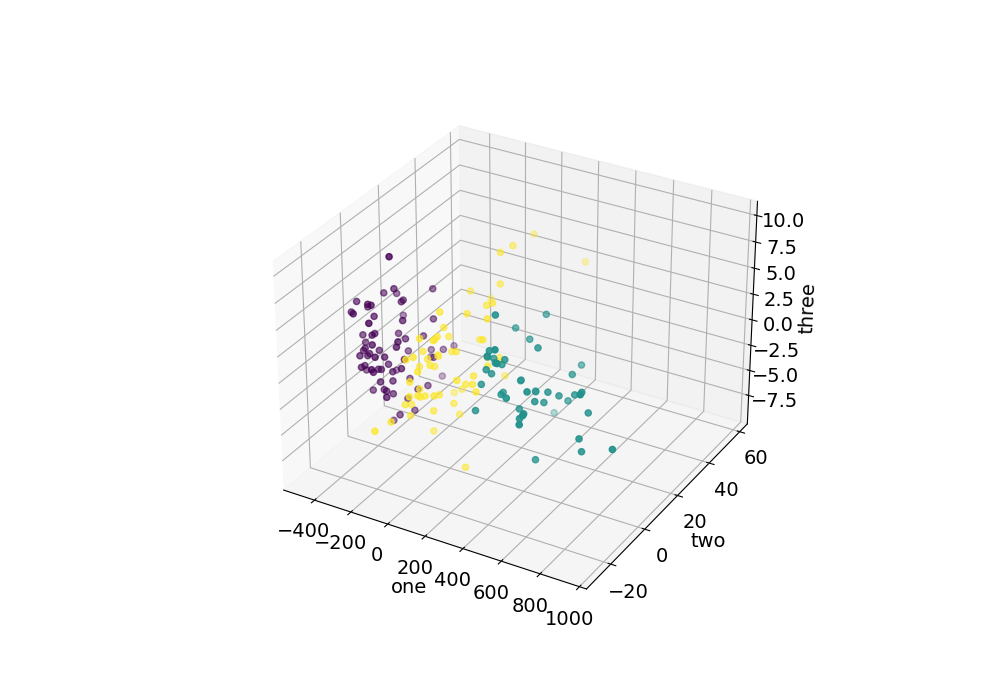

```python
# 3D Plot
fig = plt.figure()
ax = plt.axes(projection='3d')

ax.scatter3D(pca_data.one, pca_data.two, pca_data.three, c=pca_data.cluster, cmap='viridis')
ax.set_xlabel('one')
ax.set_ylabel('two')
ax.set_zlabel('three')

plt.show()
```